[figure not shown]

# WorldFitness Database

Created by Roshan Cranford Luitel

The following notebook explains the creation process of a database using MySQL for a fictional gym called WorldFitness. As someone very interested in the wellness industry, I thought it would be interesting to get a better understanding of the systems in place that allow gyms to operate smoothly.

Tools Used:

- `MySQL for database creation`
- `DBDiagram for ERD creation`
- `Mockaroo for generating random data`
- `ChatGPT for logo design`
- `Google Colab for HTML creation`

## ERD Diagram

Below is a visual of the database structure for WorldFitness Gym.

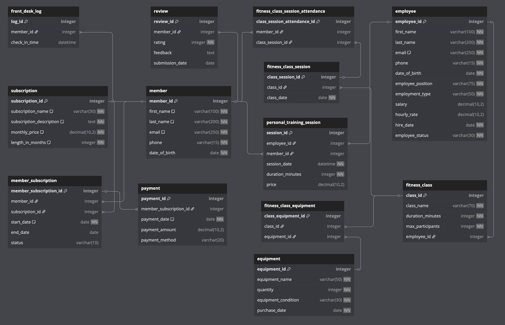

## Table Functions:

- `front_desk_log`: Tracks member check-ins at the front desk.
- `subscription`: Defines subscription plans available to members.
- `member_subscription`: Associates members with their chosen subscription plan.
- `review`: Stores feedback from members regarding their experience.
- `member`: Holds personal information of gym members.
- `payment`: Captures payment transactions linked to a member’s subscription.
- `fitness_class_session_attendance`: Records which members attend each scheduled fitness class.
- `fitness_class_session`: Represents scheduled sessions of a specific fitness class.
- `personal_training_session`: Tracks individual personal training sessions between a member and personal trainer.
- `fitness_class_equipment`: Records which gym equipment was used in a given fitness class.
- `equipment`: Keeps an inventory of gym equipment.
- `employee`: Maintains details about employees.
- `fitness_class`: Lists all fitness classes offered by the gym.

## Step 1: Create Database

The first step is to actually create the database and set it as the active database.

```
CREATE DATABASE WorldFitness;
USE WorldFitness;
```

## Step 2: Create Tables

The second step is to create tables that will store relevant data for the gym's operations and specify the data types that they will be storing. The following code shows the creation process.

```
CREATE TABLE subscription(
    subscription_id INT AUTO_INCREMENT PRIMARY KEY,
    subscription_name VARCHAR(30) NOT NULL,
    subscription_description TEXT NOT NULL,
    monthly_price DECIMAL(10,2) NOT NULL,
    length_in_months INT NOT NULL
);

CREATE TABLE member(
    member_id INT AUTO_INCREMENT PRIMARY KEY,
    first_name VARCHAR(100) CHARACTER SET utf8mb4 NOT NULL,
    last_name VARCHAR(200) CHARACTER SET utf8mb4 NOT NULL,
    email VARCHAR(250) CHARACTER SET utf8mb4 NOT NULL,
    phone VARCHAR(15) NOT NULL,
    date_of_birth DATE NOT NULL
);

CREATE TABLE member_subscription(
    member_subscription_id INT AUTO_INCREMENT PRIMARY KEY,
    member_id INT,
    FOREIGN KEY (member_id) REFERENCES member(member_id),
    subscription_id INT,
    FOREIGN KEY (subscription_id) REFERENCES subscription(subscription_id),
    start_date DATE NOT NULL,
    end_date DATE,
    status VARCHAR(10)
);

CREATE TABLE payment(
    payment_id INT AUTO_INCREMENT PRIMARY KEY,
    member_subscription_id INT,
    FOREIGN KEY (member_subscription_id) REFERENCES member_subscription(member_subscription_id),
    payment_date DATE NOT NULL,
    payment_amount DECIMAL(10,2),
    payment_method VARCHAR(20)
);

CREATE TABLE front_desk_log(
    log_id INT AUTO_INCREMENT PRIMARY KEY,
    member_id INT,
    FOREIGN KEY (member_id) REFERENCES member (member_id),
    check_in_time DATETIME
);

CREATE TABLE employee(
    employee_id INT AUTO_INCREMENT PRIMARY KEY,
    first_name VARCHAR(100) NOT NULL,
    last_name VARCHAR(200) NOT NULL,
    email VARCHAR(250) CHARACTER SET utf8mb4 NOT NULL,
    phone VARCHAR(15) NOT NULL,
    date_of_birth DATE NOT NULL,
    employee_position VARCHAR(75) NOT NULL,
    employment_type VARCHAR(50) NOT NULL,
    salary DECIMAL(10,2),
    hourly_rate DECIMAL(10,2),
    hire_date DATE NOT NULL,
    employee_status VARCHAR(30) NOT NULL
);

CREATE TABLE personal_training_session(
    session_id INT AUTO_INCREMENT PRIMARY KEY,
    employee_id INT,
    FOREIGN KEY (employee_id) REFERENCES employee (employee_id),
    member_id INT,
    FOREIGN KEY (member_id) REFERENCES member (member_id),
    session_date DATETIME NOT NULL,
    duration_minutes INT NOT NULL,
    price DECIMAL (10,2)
);

CREATE TABLE review(
    review_id INT AUTO_INCREMENT PRIMARY KEY,
    member_id INT,
    FOREIGN KEY (member_id) REFERENCES member (member_id),
    rating INT NOT NULL,
    feedback TEXT,
    submission_date DATE
);

CREATE TABLE equipment(
    equipment_id INT AUTO_INCREMENT PRIMARY KEY,
    equipment_name VARCHAR(50) NOT NULL,
    quantity INT NOT NULL,
    equipment_condition VARCHAR(30) NOT NULL,
    purchase_date DATE NOT NULL
);

CREATE TABLE fitness_class(
    class_id INT AUTO_INCREMENT PRIMARY KEY,
    class_name VARCHAR(70) NOT NULL,
    duration_minutes INT NOT NULL,
    max_participants INT NOT NULL,
    employee_id INT,
    FOREIGN KEY (employee_id) REFERENCES employee (employee_id)
);

CREATE TABLE fitness_class_equipment(
    class_equipment_id INT AUTO_INCREMENT PRIMARY KEY,
    class_id INT,
    FOREIGN KEY (class_id) REFERENCES fitness_class (class_id),
    equipment_id INT,
    FOREIGN KEY (equipment_id) REFERENCES equipment (equipment_id)
);

CREATE TABLE fitness_class_session(
    class_session_id INT AUTO_INCREMENT PRIMARY KEY,
    class_id INT,
    FOREIGN KEY (class_id) REFERENCES fitness_class (class_id),
    class_date DATE NOT NULL
);

CREATE TABLE fitness_class_session_attendance(
    class_session_attendance_id INT AUTO_INCREMENT PRIMARY KEY,
    member_id INT,
    FOREIGN KEY (member_id) REFERENCES member (member_id),
    class_session_id INT,
    FOREIGN KEY (class_session_id) REFERENCES fitness_class_session (class_session_id)
);
```